# R vs python introduction

AC Watt

12/21/2021

# 1 Introduction

The purpose of this tutorial is to compare some common features of R and python that will be implemented in ARE 212 (Econometrics: Multiple Equation Estimation). This first part will run through examples of tasks in both R and python before starting part 2, which will focus specifically on python.

R and python are both popular programming languages, here are some comparisons between the two:

- R has been adopted by the statistics community, python has been adotped by general purpose programmers
- R generally has the most cutting edge statistics packages (sometimes the only version is written in R), python has the most cutting edge Machine Learning tools
- R and python are similar in syntax (compared to other languages)
- both can execute code line-by-line or in a whole script
- both have debugging tools to help find the source of errors (the python’s error messages are often more useful)
- both use dataframes to handle data and do data cleaning tasks (R’s `tidyverse` vs python’s `pandas`)
- both can be used for API calls (getting data from some internet source) but python is frequently used for more intense web scrapping applications
- some statistical applications are shorter to write in R but easier to write and understand in python
- both R and python have methods to do very fast computations but it takes practice writing code in that way (vectorized functions, numpy arrays, etc).

# 2 Organizing your scripts

Two things I want to point out: directory structure and file structure.

## 2.1 Directory structure

When creating multiple scripts that have various outputs, it’s important to have a structure so things don’t get lost. This should be simple for a class folder, so I’ll just leave you with the following suggestion:

Regardless if you are using GitHub, consider using [Ryan Kellogg’s RA Manual page on Folder Organization](https://github.com/kelloggrk/Kellogg_RA_Manual/wiki/Folder-Organization) as a guide for organizing your project folders for research projects. It’s not as applicable for a simple class folder, but I encourage you to review his manual in detail.

## 2.2 File structure

There’s generally several parts to each script you write:

- the header
- package imports
- functions
- classes (sometimes)
- execution: use of functions/classes to get output
- comments all around

### 2.2.1 The Header

Suggested minimal information in the header:

- Name of the file (in case the contents are copy-pasta’ed)
- Author
- Date of creation or last
- Description of the purpose of the file
- (sometimes) notes about the next steps to complete the file

### 2.2.2 Package imports

It’s generally suggested in both R and python to put all your package imports at the top of the file, immediately after the header (and any compile commands). This allows readers to know easily what libraries they need to install before running the program and reduces the chances of “package not installed” errors in the middle of running the script. It immediately allows users to install the necessary packages before running the rest of the script.

### 2.2.3 Functions

Chunks of reusable code that generally have some input arguments, and either will return some new object or have some “side effect” like saving a graph to a file.

### 2.2.4 Classes

Another type of reusable code chunk, but instead of just running some lines of code and returning a value (like a function), a class creates an object that has specific attributes (values) and methods (functions that can be run on the object).

### 2.2.5 Execution

This is the area of the script where you can see the steps all come together. “Do X”, then “Do Y”, then “Plot this thing” and finally, “Save this output”.

### 2.2.6 Comments

Any code should include comments – bare minimum are the comments that will make it clear to you (the author) what each of the steps are doing. Better are comments that a random person who is relatively proficient in the language can understand why each step is executed. Code comments are a general form of documentation that is important for replicability is science. Often, good names for variables can be a substitute for comments if the names make it obvious what the line of code is doing. Don’t comment something that is obvious, e.g., `x = x + 1 # incrememnt x by one unit`.

In general:

- all functions and classes should have a comment explaining what they do, and what each of the input arguments should be.
- add comments to help the reader understand the purpose of a chunk of code
- a overarching comment at the top of the file should be updated to include the purpose of the set of functions
- you can include detailed comments on functions either at the top of the script or inside each function

**Hadley Wickham’s suggestion** (works in both python and R): “Comment your code. Each line of a comment should begin with the comment symbol and a single space: #. Comments should explain the why, not the what. Use commented lines of - and = to break up your file into easily readable chunks.”

# 3 R Markdown

**Note on how this compares with the 212 course:** When using R in Sofia’s half of 212, you could use either R scripts or R markdown – R markdown makes writing the final version that you turn in very easy. When using python in Ethan’s half of 212, you could use python in R markdown, python in your own editor (Spyder, PyCharm, Jupyter Notebook), or use python in the cloud using the Jupyter Hub that Ethan has set up for 212. There’s no PDF you turn in to Ethan (you write posts in response to questions on Piazza), so the final product is less necessary. But writing up a jupyter notebook or R markdown file will make it easier to write lengthy explanations when you come back to work on it, or if you are working on it with someone else and you send them your code.

# 4 Comparing R vs Python

## 4.1 File headers

An example file header in R markdown is

```
---
title: "R vs python introduction"
author: "AC Watt"
date: "12/21/2021"
output:
  html_document:
    toc: true
    number_sections: true
    toc_float: true
---
# Description: This is a tutorial file for the ARE 212 bootcamp. The purpose is to compare common functions in both python and R that are of use during the 212 course.
```

Note: if using a plain R script, a similar header should be added to the top of the file, commented out using `#`.

An example file header in a python script is

```
# filename: r_vs_python_intro.py
# author: AC Watt
# date: 12/21/2021
"""This is a tutorial file for the ARE 212 bootcamp. The purpose is to compare common functions in both python and R that are of use during the 212 course."""
```

The triple quote `"""` is a python syntax to write long strings that may take multiple lines. Most often used for docstrings (documentation strings on scripts, functions, and classes).

## 4.2 Package Imports

In both R and python, some commonly used functions live outside of the basic features of the language. They live in “packages” that need to be imported in order to use those functions. For example, plotting is commonly done using the `ggplot2` package in R and the `matplotlib` package in python. Here’s how you would install and import the ggplot2 package in R (we’ll show how to plot later).

```r
# install.packages("ggplot2")  # only need to run this once ever for each computer
library(ggplot2)
```

You could then use `ggplot2` later using `ggplot` commands. We’ll discuss what this does later, but a common plotting command would look like

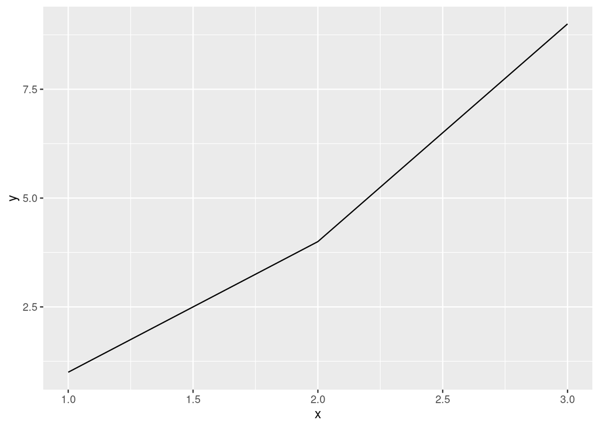

```r
# Plot the x and y columns from the dataframe `data`
data = data.frame(x=c(1,2,3), y=c(1,4,9))
p = ggplot(data) + geom_line(aes(x,y))
p
```

To import and use matplotlib in python to plot, we would import the submodule `pyplot` from `matplotlib` (a package living within `matplotlib`). In python, it’s common to rename packages you import as short variables for easy accessing later.

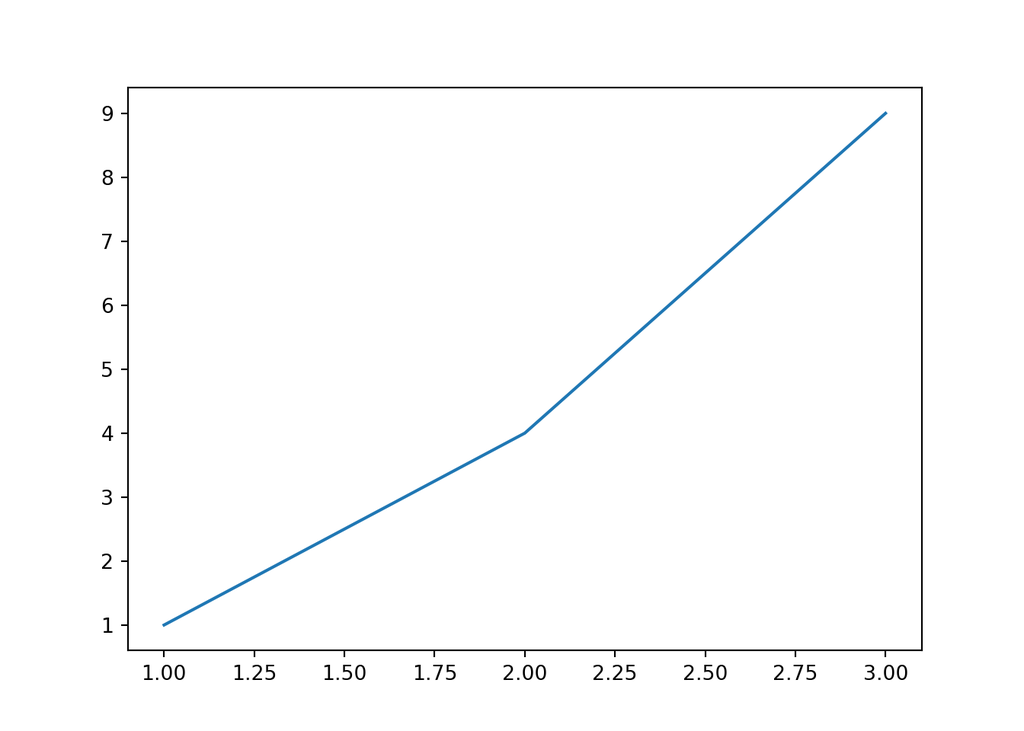

```python
import matplotlib.pyplot as plt

x = [1,2,3]
y = [1,4,9]

plt.plot(x, y)
plt.show()
```

# 5 Other notes

## 5.1 Code Style

Coding style is a set of guidelines to follow when formatting your code. Lots of code can run equally well, but much code is hard to read and debug. Following a style can help – consider following [Hadley Wickham’s R style guide](http://adv-r.had.co.nz/Style.html), and the [PEP 8 python style guide](https://pep8.org/).

# 6 Navigation links

- Using python in R markdown notes
- 212 Bootcamp Part 2: Python optimization application